# git concepts simplified

# 8.2 detached HEAD and all that

All this time you have seen HEAD pointing to a branch name, and the branch itself pointing to a commit. Then, when you make a commit, the branch moves to the new commit (although HEAD still continue to point to the branch name). If you want to recap, here’s a look at just the part of the tree that concerns us, in a simple before/after display:

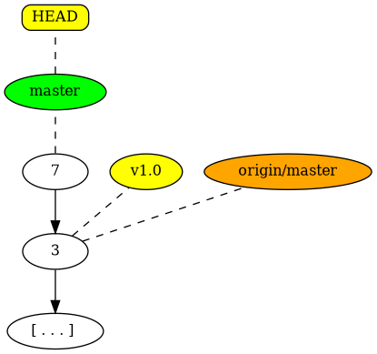

before commit

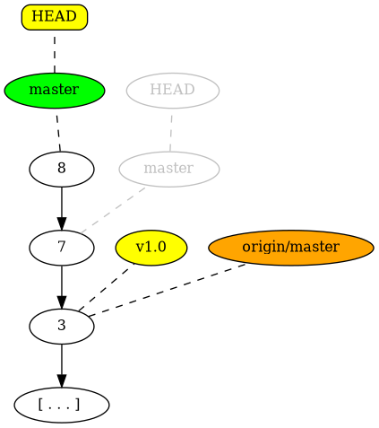

after commit

Now see what happens when you `git checkout v1.0`:

Notice the subtle difference? HEAD is no longer a **symbolic** ref (i.e., pointing to a real branch). Instead, it is pointing directly to a commit.

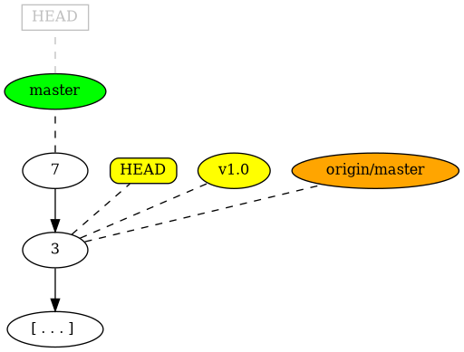

after checkout v1.0

In real terms, this is literally what happens. When you had “master” checked out, the contents of HEAD (it’s just a file in .git) are simply

```
ref: refs/heads/master
```

If you `git checkout devel` (which is a local branch), it becomes

```
ref: refs/heads/devel
```

However, remember what we said earlier? Only branches can move, tags cannot. So when you `git checkout v1.0`, HEAD now contains

```
90fed7792746a9a33e24059fb171f6bbb6ffebe6
```

or some such hash. If it did what it did for local branches, it would imply the tag would move, right? Which it shouldn’t – wouldn’t be much of a tag if it moved!

So from this point on, if you make a commit, only HEAD changes, nothing else, since it is no longer “attached” to any local branch name"

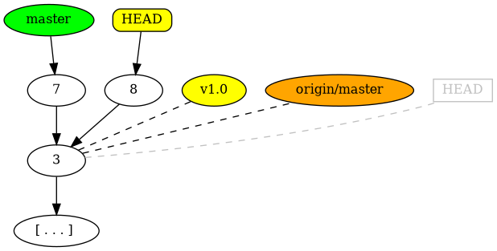

commit on detached HEAD

The reason this is considered dangerous is that, if you now do `git checkout master`, you get this:

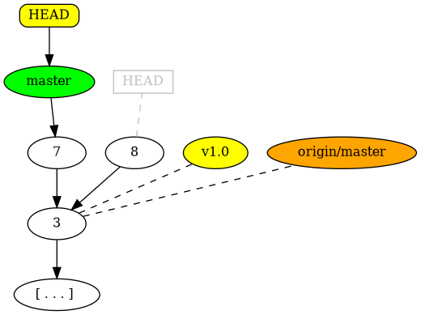

unreachable commit

Notice what happened to your new commit 8? It’s dangling. Unreachable. (Except by the reflog, of course, but beginners can get shaken up!)

# 8.3 other ways to detach your HEAD

The most common way to get into a detached HEAD state is to check out a remote branch (like `git checkout origin/branch`), without realising that you need to make a local copy before you make commits on it.

(Side note: the correct syntax to create and checkout a local branch starting from a remote branch used to be `git checkout -t -b branch origin/branch`, but modern gits will do the right thing if you simply say `git checkout branch`; yaay for progress!)

The reason `git checkout origin/branch` creates a detached HEAD is that, while remote branches can move, they can only do so as a result of a `git fetch` or equivalent. After all, they are meant to track what the *remote* has, so it wouldn’t make sense for them to acquire *local* commits!

Here are various ways to detach HEAD:

```
git checkout origin/master  # (described above)
git checkout master^        # parent of master
git checkout HEAD~2         # grandparent of current HEAD
git checkout tagname        # since you cant commit to a tag!
git checkout <SHA>          # hex digits forming a full or partial SHA
git checkout master^0       # (see note below)
```

These will all make the file called `HEAD` contain the actual (40-hex-digit) SHA of the corresponding commit instead of some string like `ref: refs/heads/branch`.

That last one (`git checkout master^0`) is interesting. The `master^0` notation means “the actual commit that master points to”, so it’s just like saying `git checkout <SHA>`.

# 8.4 re-attaching the HEAD

Modern git will warn you about losing commits on a detached HEAD if you’re at the command line, and tell you how to recover (immediately).

Recovery is quite easy. If you realised you’re on a detached HEAD *before* you switched to some other branch:

```
git checkout -b newbranch
```

If you switched, possibly made some commits, and *then* realised you lost some commits on a detached HEAD, you need to check the reflog to find the lost HEAD and switch to that using some command like:

```
git branch newbranch HEAD@{1}
```

# 8.5 the reflog

The reflog can show you all the values that HEAD has taken in the past. Here’s a simulated example. I cloned a repo that had a master and a ‘foo’ branch. I then checked out `origin/foo`, ignored all the warnings, and made two commits on what I thought was the “foo” branch. Then I switched back to master and made two normal commits on master before I realised that I had ‘lost’ two commits.

At this point, running `git reflog show` gives me the following (the most recent HEAD value is first):

```
86a8ee0 HEAD@{0}: commit: my second commit on master
e42c4d0 HEAD@{1}: commit: my first commit on master
58c1539 HEAD@{2}: checkout: moving from e2558a9d1527e5a76b39ffede1dc5ca9c650de01 to master
e2558a9 HEAD@{3}: commit: second commit on foo
1c9dfa0 HEAD@{4}: commit: first commit on foo
802f184 HEAD@{5}: checkout: moving from master to origin/foo
58c1539 HEAD@{6}: clone: from /tmp/tmp.lv5IqjK0ZI/b
```

That `moving from <SHA>...` is usually a sign that some commits may have been lost. In this case you can run `git branch newbranch HEAD@{3}` or `git branch newbranch e2558a9` to save those commits. (Notice that the SHA value of `HEAD@{3}` is the same one mentioned in the `moving from <SHA>...` message on the line above it).

# 8.6 The end

Hope that was useful…!